# R Notebook

```r
# install.packages('UsingR')
library(UsingR)
data(normtemp)
```

## Use the normtemp dataset to answer the following:

### Determine the following statistics for the variable temperature:

```
    Minimum: 96.30

    Maximum: 100.80

    Mean: 98.25

    Standard Deviation: 0.7331832
```

```r
summary(normtemp)
```

```
  temperature         gender          hr
 Min.   : 96.30   Min.   :1.0   Min.   :57.00
 1st Qu.: 97.80   1st Qu.:1.0   1st Qu.:69.00
 Median : 98.30   Median :1.5   Median :74.00
 Mean   : 98.25   Mean   :1.5   Mean   :73.76
 3rd Qu.: 98.70   3rd Qu.:2.0   3rd Qu.:79.00
 Max.   :100.80   Max.   :2.0   Max.   :89.00
```

```r
sd(normtemp$temperature)
```

```
[1] 0.7331832
```

### Does temperature appear to be normally distributed?

Yes, the distribution of temperature looks to be Normally distributed visually.

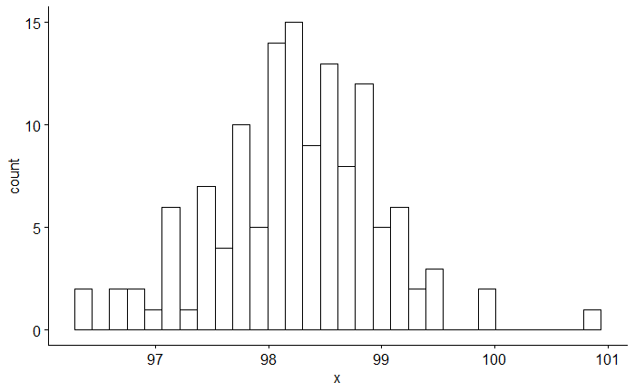

```r
# install.packages("ggpubr")
library(ggpubr)
gghistogram(normtemp$temperature) # Use ggpubr gghistogram to speed up graph making
```

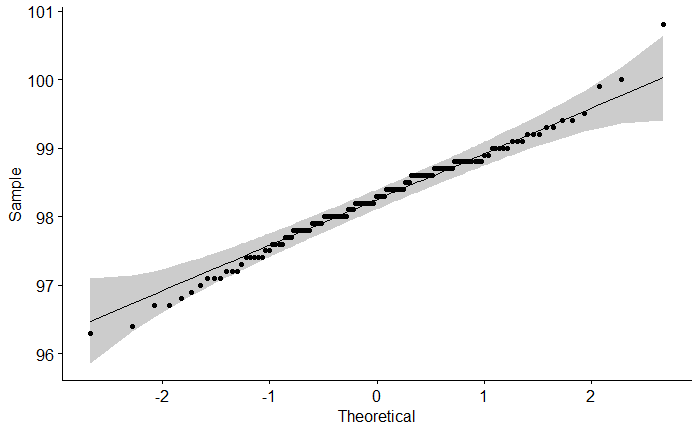

```r
ggqqplot(normtemp$temperature)
```

### Create box plots for temperature. Are there any outliers? Display a reference line at 98.6. Does the median body temperature seem to be 98.6 degrees?

No, the median temperature seems to be lower than 98.6. There does seem to be 3 outliers, two lower and one upper

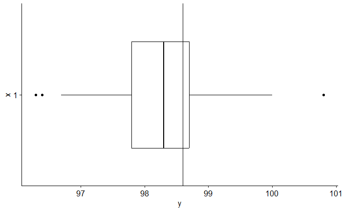

```r
ggboxplot(normtemp$temperature) +
  geom_hline(yintercept = 98.6) +
  coord_flip()
```

## Using the Ameshousing dataset from our in-class examples, run some distributional analysis on Sale_Price, Log(Sale_Price), and Gr_Liv_Area

### Create histograms of these three variables

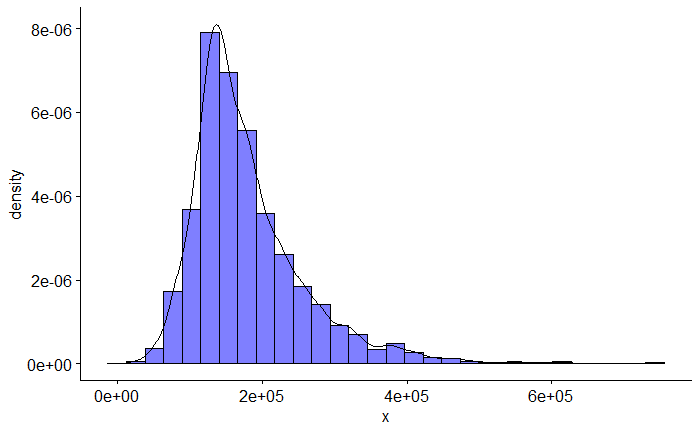

```r
library(AmesHousing)
ames <- make_ordinal_ames()
gghistogram(ames$Sale_Price, y='density', fill = 'blue', alpha = 0.5) +
  geom_density(alpha = 0.5)
```

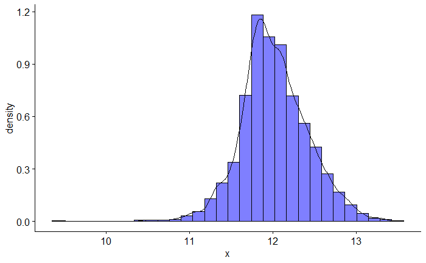

```r
gghistogram(log(ames$Sale_Price), y='density', fill = 'blue', alpha = 0.5) +
  geom_density(alpha = 0.5)
```

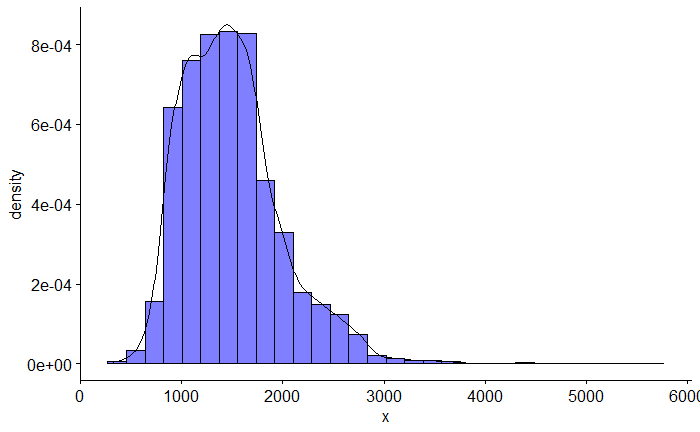

```r
gghistogram(ames$Gr_Liv_Area, y='density', fill = 'blue', alpha = 0.5) +
  geom_density(alpha = 0.5)
```

### Create a QQ Plot for both Sale_Price and Log(Sale_Price). Based on these exploratory procedures, which version of the price information (Sale_Price or Log(Sale_Price)) would you say is closer to being normally distributed?

The log of Sale_Price looks closer to Normal than the unchanged Sale_Price distribution.

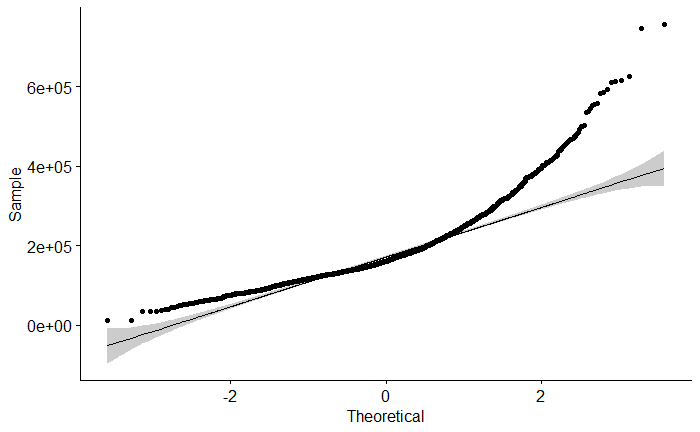

```r
ggqqplot(ames$Sale_Price)
```

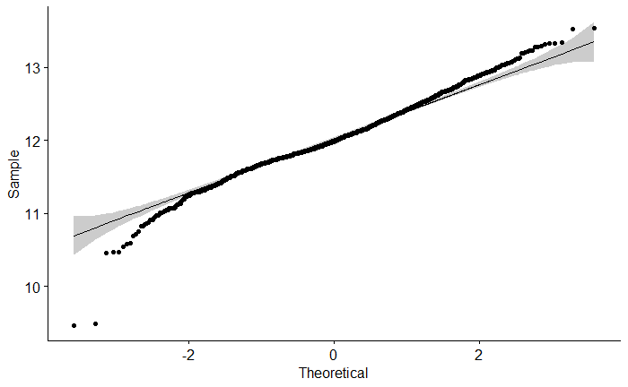

```r
ggqqplot(log(ames$Sale_Price))
```

## Using the Ameshousing dataset from our in-class examples, determine the following:

### What type of variables are each of these columns (Nominal, Ordinal, or Continuous/Quantitative)? Keep in mind that the way they are represented in the R dataset may not be appropriate, so you should make this determination using your own judgement based on the data you are looking at.

- Overall_Qual: Ordinal
- Lot_Shape: Ordinal
- Heating_QC: Ordinal
- Lot_Area: Quantitative

```r
str(ames)
```

```
tibble [2,930 × 81] (S3: tbl_df/tbl/data.frame)
 $ MS_SubClass       : Factor w/ 16 levels "One_Story_1946_and_Newer_All_Styles",..: 1 1 1 1 6 6 12 12 12 6 ...
 $ MS_Zoning         : Factor w/ 7 levels "Floating_Village_Residential",..: 3 2 3 3 3 3 3 3 3 3 ...
 $ Lot_Frontage      : num [1:2930] 141 80 81 93 74 78 41 43 39 60 ...
 $ Lot_Area          : int [1:2930] 31770 11622 14267 11160 13830 9978 4920 5005 5389 7500 ...
 $ Street            : Factor w/ 2 levels "Grvl","Pave": 2 2 2 2 2 2 2 2 2 2 ...
 $ Alley             : Factor w/ 3 levels "Gravel","No_Alley_Access",..: 2 2 2 2 2 2 2 2 2 2 ...
 $ Lot_Shape         : Ord.factor w/ 4 levels "Irregular"<"Moderately_Irregular"<..: 3 4 3 4 3 3 4 3 3 4 ...
 $ Land_Contour      : Ord.factor w/ 4 levels "Low"<"HLS"<"Bnk"<..: 4 4 4 4 4 4 4 2 4 4 ...
 $ Utilities         : Ord.factor w/ 4 levels "ELO"<"NoSeWa"<..: 4 4 4 4 4 4 4 4 4 4 ...
 $ Lot_Config        : Factor w/ 5 levels "Corner","CulDSac",..: 1 5 1 1 5 5 5 5 5 5 ...
 $ Land_Slope        : Ord.factor w/ 3 levels "Sev"<"Mod"<"Gtl": 3 3 3 3 3 3 3 3 3 3 ...
 $ Neighborhood      : Factor w/ 29 levels "North_Ames","College_Creek",..: 1 1 1 1 7 7 17 17 17 7 ...
 $ Condition_1       : Factor w/ 9 levels "Artery","Feedr",..: 3 2 3 3 3 3 3 3 3 3 ...
 $ Condition_2       : Factor w/ 8 levels "Artery","Feedr",..: 3 3 3 3 3 3 3 3 3 3 ...
 $ Bldg_Type         : Factor w/ 5 levels "OneFam","TwoFmCon",..: 1 1 1 1 1 1 5 5 5 1 ...
 $ House_Style       : Factor w/ 8 levels "One_and_Half_Fin",..: 3 3 3 3 8 8 3 3 3 8 ...
 $ Overall_Qual      : Ord.factor w/ 10 levels "Very_Poor"<"Poor"<..: 6 5 6 7 5 6 8 8 8 7 ...
 $ Overall_Cond      : Ord.factor w/ 10 levels "Very_Poor"<"Poor"<..: 5 6 6 5 5 6 5 5 5 5 ...
 $ Year_Built        : int [1:2930] 1960 1961 1958 1968 1997 1998 2001 1992 1995 1999 ...
 $ Year_Remod_Add    : int [1:2930] 1960 1961 1958 1968 1998 1998 2001 1992 1996 1999 ...
 $ Roof_Style        : Factor w/ 6 levels "Flat","Gable",..: 4 2 4 4 2 2 2 2 2 2 ...
 $ Roof_Matl         : Factor w/ 8 levels "ClyTile","CompShg",..: 2 2 2 2 2 2 2 2 2 2 ...
 $ Exterior_1st      : Factor w/ 16 levels "AsbShng","AsphShn",..: 4 14 15 4 14 14 6 7 6 14 ...
 $ Exterior_2nd      : Factor w/ 17 levels "AsbShng","AsphShn",..: 11 15 16 4 15 15 6 7 6 15 ...
 $ Mas_Vnr_Type      : Factor w/ 5 levels "BrkCmn","BrkFace",..: 5 4 2 4 4 2 4 4 4 4 ...
 $ Mas_Vnr_Area      : num [1:2930] 112 0 108 0 0 20 0 0 0 0 ...
 $ Exter_Qual        : Ord.factor w/ 5 levels "Poor"<"Fair"<..: 3 3 3 4 3 3 4 4 4 3 ...
 $ Exter_Cond        : Ord.factor w/ 5 levels "Poor"<"Fair"<..: 3 3 3 3 3 3 3 3 3 3 ...
 $ Foundation        : Factor w/ 6 levels "BrkTil","CBlock",..: 2 2 2 2 3 3 3 3 3 3 ...
 $ Bsmt_Qual         : Ord.factor w/ 6 levels "No_Basement"<..: 4 4 4 4 5 4 5 5 5 4 ...
 $ Bsmt_Cond         : Ord.factor w/ 6 levels "No_Basement"<..: 5 4 4 4 4 4 4 4 4 4 ...
 $ Bsmt_Exposure     : Ord.factor w/ 5 levels "No_Basement"<..: 5 2 2 2 2 2 3 2 2 2 ...
 $ BsmtFin_Type_1    : Ord.factor w/ 7 levels "No_Basement"<..: 5 4 6 6 7 7 7 6 7 2 ...
 $ BsmtFin_SF_1      : num [1:2930] 2 6 1 1 3 3 3 1 3 7 ...
 $ BsmtFin_Type_2    : Ord.factor w/ 7 levels "No_Basement"<..: 2 3 2 2 2 2 2 2 2 2 ...
 $ BsmtFin_SF_2      : num [1:2930] 0 144 0 0 0 0 0 0 0 0 ...
 $ Bsmt_Unf_SF       : num [1:2930] 441 270 406 1045 137 ...
 $ Total_Bsmt_SF     : num [1:2930] 1080 882 1329 2110 928 ...
 $ Heating           : Factor w/ 6 levels "Floor","GasA",..: 2 2 2 2 2 2 2 2 2 2 ...
```

[output cut: 196 more lines]

[output not shown]